# 2019 CLB & ERA Report Stock Composition Figures

# Introduction

Table 1. Stock Group Definitions

| Stock Group | Description |
| --- | --- |
| ORCST | Oregon Coast |
| CR | Columbia River |
| WACST | Washington Coast |
| PSD | Puget Sound |
| FR-late | Fraser Late |
| FR-early | Fraser Early |
| GS | Georgia Strait |
| WCVI | West Coast Vancouver Island |
| NCBC | North and Central B.C. |
| SEAK | Southeast Alaska |
| NONE$^1$ | None |
| UNK$^2$ | Unknown (i.e. Unsampled) |

$^1$ Stock group NONE is comprised of stocks not represented and is contingent on the version of the Chinook Model.

$^2$ UNK is not a stock group per se because it is the unsampled catch. GSI estimates are only available for the portion of the catch sampled for genetics, which may not be the same as the total catch.

## Estimating Stock Composition from the Chinook Model

Estimating stock composition from the Chinook Model is simple. First, the proportion of landed catch by model stock is computed as:
$$P_{F,S,Y} = \frac{Q_{F,S,Y}}{\sum_S{Q_{F,S,Y}}}$$
where $Q_{F,S,Y}$ is the model landed catch by fishery $F$, stock $S$, and year $Y$. Second, the landed catch stock composition is computed as:
$$C_{F,S,Y} = C_{F,Y}*P_{F,S,Y}$$
where $C_{F,Y}$ is the reported landed catch by fishery $F$ and year $Y$. Lastly, since the Chinook Model does not account for the Alaska Hatchery Addon, the landed catch stock composition is adjusted by:
$$C_{F,S=AK,Y} = C_{F,S=AK,Y} + A_{F,S=AK,Y}$$
where $A_{F,S=AK,Y}$ is the Alaska Hatchery Addon by fishery $F$ and year $Y$ for only the Alaska Stock Group - $S=AKS$ in clb1804 or $S=NSA$ and $S=SSA$ in Phase 2. The Alaska Hatchery Addon adjustment is necessary so that model-based estimates of landed catch stock composition are comparable to gsi-based estimates.

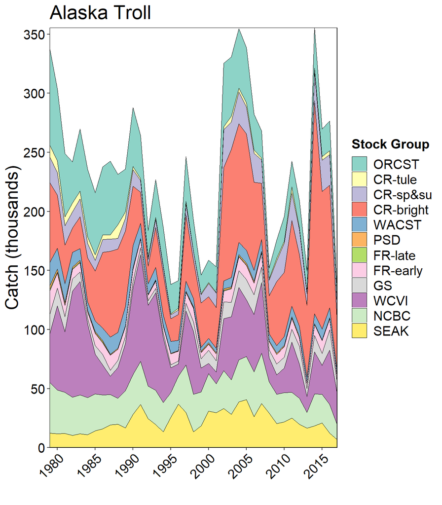

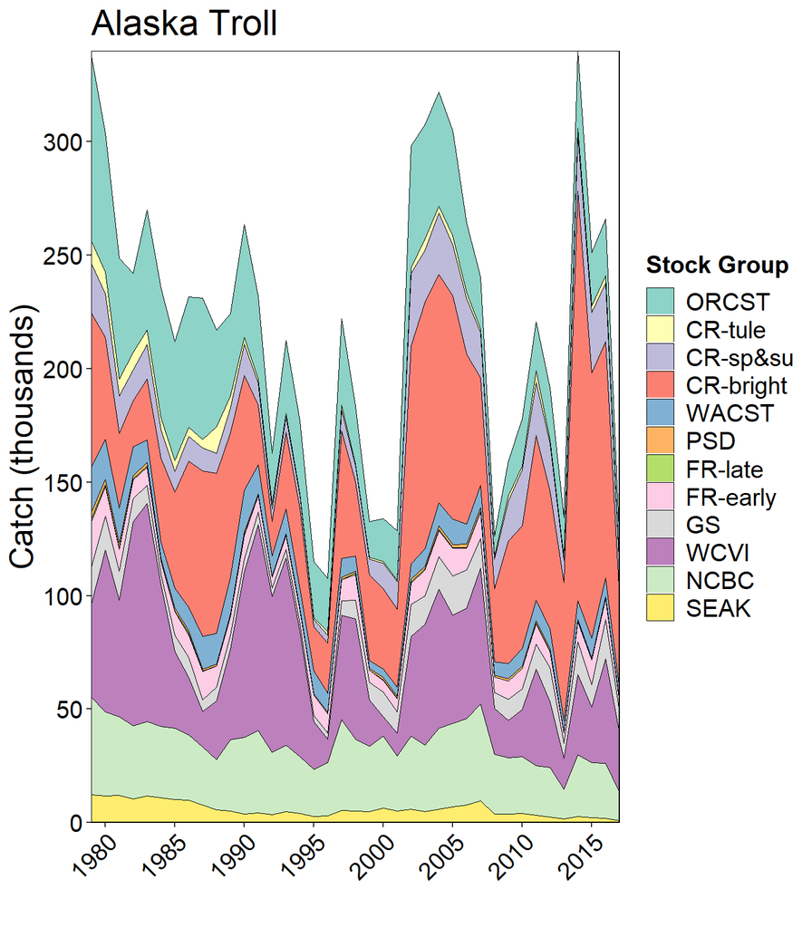

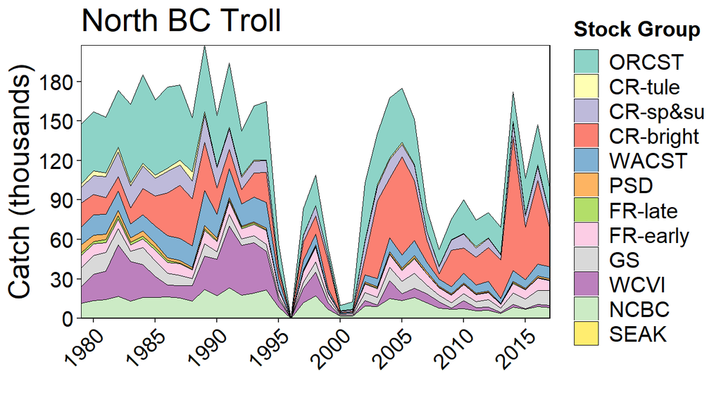